# Assignment3

```python
import pandas as pd
import altair as alt
import numpy as np
```

```python
df_Stock = pd.read_csv("GME.csv")
df_Stock = df_Stock[['Date', 'Close']]
df_Stock['Date'] = pd.to_datetime(df_Stock.Date)
df_Stock['Date'] = df_Stock['Date'].dt.strftime('%m/%d/%Y')
# df_Stock.head()
```

```python
df_WSB = pd.read_csv("WSB_Google.csv")
df_WSB['wallstreetbets'] = np.where((df_WSB.wallstreetbets == '<1'), 1, df_WSB.wallstreetbets)
df_WSB['wallstreetbets'] = pd.to_numeric(df_WSB['wallstreetbets'])
df_WSB['Date'] = pd.to_datetime(df_WSB.Date)
df_WSB['Date'] = df_WSB['Date'].dt.strftime('%m/%d/%Y')
# df_WSB.head(100)
```

```python
df_merge = pd.merge(df_Stock, df_WSB, on = ['Date'], how='inner')
```

```python
df_merge.head()
```

|  | Date | Close | wallstreetbets |
| --- | --- | --- | --- |
| 0 | 12/07/2020 | 16.350000 | 1 |
| 1 | 12/08/2020 | 16.940001 | 1 |
| 2 | 12/09/2020 | 13.660000 | 1 |
| 3 | 12/10/2020 | 14.120000 | 1 |
| 4 | 12/11/2020 | 13.310000 | 1 |

# **Precondition**

## **1. Learning**

GameStop is a classic brick and mortar style store that specializes in the retail sale of hardcopy video games and gaming equpment. It is without a doubt that online retail entities have secured a large amoutn of market capital from GameStop over the last few years. This decline was matched by large investment firms who bet a **generous** amount of money that the companies stock would continue its downward trend. They made these bets in the form of shorts, or rather, they sold shares with a promise that they would have to buy them back later in the future. If GME fell in price, they would have a lucrative profit. However, if GME failed to fall, short-sellers would have to buy back their shares at the current price (causing a price surge). A few individuals apart of the r/wallstreetbets reddit community realized the opportunity, brought the entire reddit community together, and collectively bought and held many GME shares in order to keep the price high as hedge funds were forced to buy back shorted shares at the current, inflated price. This caused massive surges in the stock price. The little guy profited, the hedge funds lost it all, and the SEC and exchanges have proven to be one of the most curropt entities in history.  
**Problem:** Has the Internet, Specifically the r/wallstreetbets Reddit Forum, Played a Big Role in the 'Meme' Stock Price GME Fiassco?

## **2. Winnowing**

In order to explore our problem, I have chosen two datasets to analyze.  
**1. GME Closing Price Data from the NYSE**  
Source: Yahoo Finance https://finance.yahoo.com/quote/GME/history/  
This is data reflects the closing price of the GME stock on the NYSE. It is completely unbiased and purlely represents the historical price action of the stock. This data will be useful to track the value of the GME stock over time and be able to compare it to external factors that may have caused its volatility.  
**2. "wallstreetbets" Google Search Popularity**  
Source: Google Trends https://trends.google.com/trends/explore?date=today%203-m&q=wall%20street%20bets  
This data reflects the frequency that the term "wallstreetbets" was searched on the Google Search Engine. It is also unbiased because if represents historical frequency data. Google Trends has ranked the search frequency with a rating between 0-100 (Less frequent - More frequent). This data will be useful in comparing to GME's historical stock price action. We will be able to see if trends align or not to find out if there is a a correlation between the google search frequency of thge term "wallstreetbets" and the price of the GME stock.

# Core

## **3. Discover**

**Task 1: Simultaneously Plot GME Closing Price and WallStreetBets Search Popularity in a Effective Visual Model**  
Why: We wish to view the historical movement of our data over a range of time. Thus we will be able to identify how time has effected the change in data  
How: We will plot both data sets using consistent x axis in the form of dates over a certain range in time. We will use a line graph to connect datapoints to create a visually appealing representation of the trend of the data.  
What: The Task will seek to allow users to clearly undertand the drastic and unprecedented change in the dataset during the weeks prior and after to the first phase of the GME short squeeze.  
When: The Task is performed after 3/4/2021. This historical set encompasses the entirety of the first phase of the GME short squeeze.  
Who: I will be running the task now on 4/8/2021 using jupyter notebook/python to process the data and altair to execute the visualizations  
**Task 2: Show there is a correlation between GME Stock Price and wallstreet bets popularity**  
Why: We wish to seek an explanation toward the unprecedented price movement of the GME stock  
How: We will look at the Google search popularity of the wallstreetbets forum compared to closing prices of the GME stock over the same range of dates  
What: The task will seek to reveal correlation between the change in the popularity of the search term "wallstreetbets" and the GME stock price. A User will be able to select a group of dates to highlight movement trends between both sets of data.  
Where: The task will operate between historical data from 12/7/2020-3/4/2021 Using target data from YahooFinance and GoogleTrends  
When: The Task is performed after 3/4/2021. This historical set encompasses the entirety of the first phase of the GME short squeeze.  
Who: I will be running the task now on 4/8/2021 using jupyter notebook/python to process the data and altair to execute the visualizations

## **4. Design**

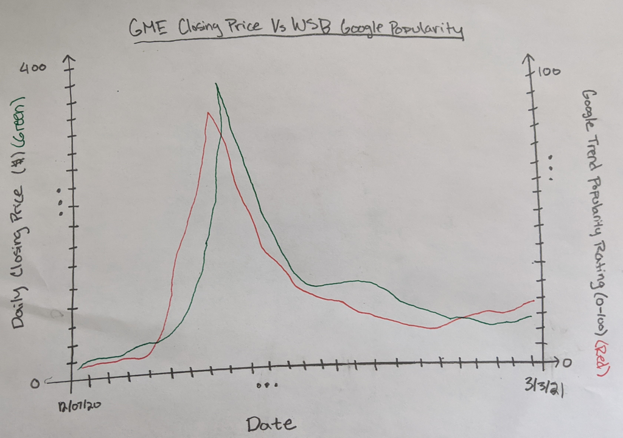

## **5. Implement**

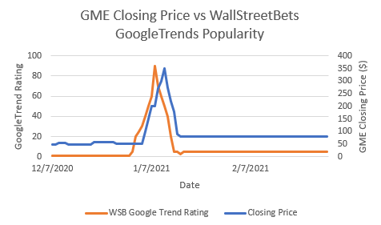

This implementation consists of overlayed lineplots sharing an x axis with independent y axis. The visualization allows us to track changes in each dataset over the same period of time. If changes occur in both sets around the same time, we may be able to draw correlation between the two sets.

## **6. Deploy**

```python
base2 = alt.Chart(df_merge).encode(alt.X('Date', axis=alt.Axis(title='Date'))).properties(title = 'GME Closing Price (Red) VS Wall Street Bets Google Popularity (Blue)')
line1 = base2.mark_line(color="red").encode(y=alt.Y('Close', axis=alt.Axis(title='Daily Closing Price ($)')))
line2 = base2.mark_line().encode(y=alt.Y('wallstreetbets', axis=alt.Axis(title='Google Trend Popularity (0-100)')))

alt.layer(line1, line2).resolve_scale(y = 'independent')
```

[interactive chart not shown]

We see that there is significant correlation between the two datasets. What is interesting, however, is that it appears the decline in search popularity of WallStreetBets spurred the decrease in the GME stock price. The second spike in search popularity could be explained because an influx of people searched the term during the rapid decrease of the GME price.

## **7. Iterate**

One Task I would like to conduct is being able to interract with both graphs simultaneously to be able to highlight certain ranges of time to compare price/popularity movements in the data

```python
base = alt.Chart(df_merge).mark_line().encode(
    x=alt.X('Date', axis=alt.Axis(title='Date')),
    y=alt.Y(alt.repeat('column'), type='quantitative')
    ).properties(title = 'GME Closing Price VS Wall Street Bets Google Popularity',
    width=600, height=300)

brush = alt.selection(type='interval', encodings=['x'])

background = base.encode(
    color=alt.value('#ddd')
    ).add_selection(brush)

highlight = base.transform_filter(brush)


alt.layer(background, highlight, data=df_merge).repeat(column=["Close", "wallstreetbets"])
```

[interactive chart not shown]

## **Use Cursor To Highlight range of graph, the highlighted section can be moved to other sections of the graph**

# Analysis

## **8. Reflect Pt1**

This visualization clearly shows that there is a correlation between the popularity of the search term "wallstreetbets" and the price action of the GME stock. This helps us conclude that the internet, more specifically the r/wallstreetbets reddit community, was a major driving factor in the unprescedented GME short squeeze. To dive deeper, it appears that the decline in the search popularoty of the term actually may have been a factor in the beginning of the decline in the stock price. At the stock's peak, the popularity of the search term hit a local minimum. As the stock price began to fall sharply, people became curius once again hitting another local maximum, followed by a sharp decline.

## **9. Reflect Pt2**

This visualization shows that we can turn messy, large datasets into something easily interpreted by the average human. This is the power of data visualization, especially as we enter the age of big data. As datasets surpass our intellectual capabilities, we must rely on computers and data scientists to reconstruct the data into something with meaning.